# Analysis of MIMICIII ICU Data for Sepsis Cases

## 1. Table Join and Feature Description

Tables used:

- `patients`
- `icustays`
- `chartevents`
- `outputevents`
- `d_items`

### Personal Info Features

- `subject_id`: Number for each patient
- `icustay_id`: Number for each ICU case
- `age`: Patient's age
- `gender`: Patient's gender
- `marital_status`: Marital status of the patient
- `ethnicity`: Ethnicity of the patient
- `icu_duration_hour`: Time spent in ICU
- `icu_times`: The ith time being admitted to ICU
- `icu_times_total`: Total number of times admitted to ICU
- `icu_times_sepsis`: The ith time admitted to ICU because of sepsis
- `icu_times_total_sepsis`: Total times admitted to ICU because of sepsis
- `hospital_expire_flag`: Died in hospital
- `expire_flag`: Died eventually
- `died_immediately`: Died in hospital or within 24h after leaving hospital

## 2. Test Labels Selection

### **What desease should we analyze? Why sepsis?**

Since there are many different diseases in MIMICIII and it would be more efficient if we choose only one disease to analyze.

First we analyze the number of different diseases.

```
                               diagnosis   num
0                                NEWBORN  7718
1                              PNEUMONIA  1619
2                                 SEPSIS  1250
3               CONGESTIVE HEART FAILURE   993
4                CORONARY ARTERY DISEASE   890
...                                  ...   ...
14983         ETOH WITHDRAWAL;CHEST PAIN     1
14984          ETOH WITHDRAWAL;CIRRHOSIS     1
14985        ETOH WITHDRAWAL;EKG CHANGES     1
14986  ETOH WITHDRAWAL;FAILURE TO THRIVE     1
14987                               None     1

[14988 rows x 2 columns]
```

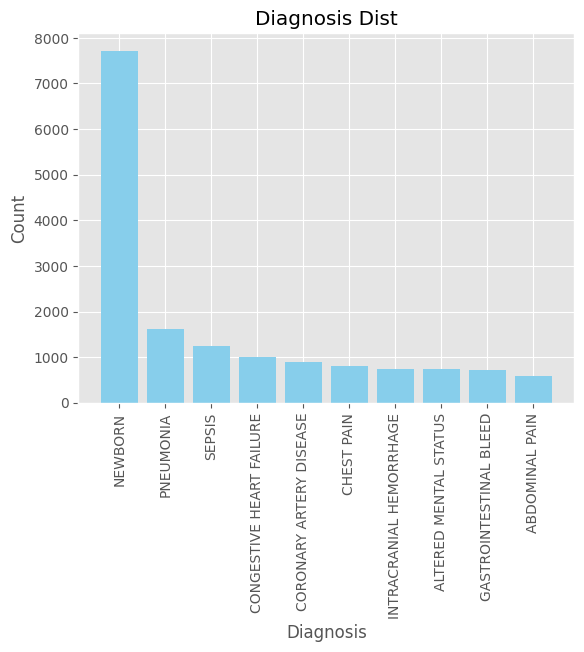

```python
import numpy as np
import pandas as pd
import matplotlib.pyplot as plt
import psycopg2
from IPython.display import display, HTML

plt.style.use('ggplot')

sqluser = 'postgres'
dbname = 'mimic'
schema_name = 'mimiciii_generate'
password = '012500'
con = psycopg2.connect(dbname=dbname, user=sqluser, password=password)
query_schema = 'set search_path to ' + schema_name + ';'

diag_only_query = '''
select distinct diagnosis, count(distinct icustay_id) as num
from mimiciii_generate.patients_all
where subject_id is not null
group by diagnosis
order by diagnosis asc;
'''
diagnosis_num = pd.read_sql_query(diag_only_query, con)
diagnosis_num = diagnosis_num.sort_values(by='num',ascending=False).reset_index(drop=True)
print(diagnosis_num)
#diagnosis_num.to_csv(r'F:\STUDY\python_code\Pract_DA\prepocess\all_diag.csv')

sepsis_top10 = diagnosis_num.head(10)
plt.bar(sepsis_top10['diagnosis'], sepsis_top10['num'],color='skyblue')
plt.title('Diagnosis Dist')
plt.xlabel('Diagnosis')
plt.xticks(rotation=90)
plt.ylabel('Count')
plt.show()
```

It turns out that, except for newborn, sepsis has the second highest number of cases. Besides, sepsis is one of the most deadly diseases in the United States. Therefore, we choose **sepsis** as our subject.

### **What tests should be considered?**

Since there are hundreds of medical tests in MIMICIII, it would be very time consuming to process all of these test values and take all of them into account. Therefore, we will select a small part of these tests to be our features.

We calculated the proportion of patients participating in each type of test. As shown in the code below, and we select the **top 20** tests. Some tests are actually the same test but with different names, we regard them together as one test.

```python
import numpy as np
import pandas as pd
import matplotlib.pyplot as plt
import psycopg2
from IPython.display import display, HTML

plt.style.use('ggplot')

sqluser = 'postgres'
dbname = 'mimic'
schema_name = 'mimiciii_generate'
password = '012500'
con = psycopg2.connect(dbname=dbname, user=sqluser, password=password)
query_schema = 'set search_path to ' + schema_name + ';'

patient_sepsis_complete_query = '''
WITH   patient_sepsis as (
        select * from mimiciii_generate.patient_sepsis_complete
        )
        select * from patient_sepsis

'''

patient_sepsis_complete = pd.read_sql_query(patient_sepsis_complete_query, con)
case_num = patient_sepsis_complete['icustay_id'].nunique()
test_counts = patient_sepsis_complete.groupby('test_label')['icustay_id'].nunique()
test_percent = (test_counts / case_num * 100).round(2).reset_index()
test_percent.columns = ['test_label', 'test_percent']
test_percent = test_percent.sort_values(by='test_percent', ascending=False).reset_index(drop=True)
print(test_percent)
```

```
               test_label  test_percent
0        Glucose (70-105)         61.80
1     Potassium (3.5-5.3)         61.80
2        Sodium (135-148)         61.75
3              Hematocrit         61.64
4      Chloride (100-112)         61.59
...                   ...           ...
1250   Erythromycin Oint.          0.05
1251                 FIO2          0.05
1252    FIO2 Alarm [High]          0.05
1253     FIO2 Alarm [Low]          0.05
1254  KCL-10 MEQ-DIALYSIS          0.05

[1255 rows x 2 columns]
```

The final selected medical test lables are as shown below.

[output not shown]

#### **Min, Max, and Avg Calculations for Each Test

Example for Glucose:

- Min: 70
- Max: 105
- Avg: Calculated from available data

#### Exception: for Heart Rhythm, which is in text value, we calculate the mode and the last value of the patient.

## 3. Pre-process

### Last Case Handling

Since the same patient will have similar test values, which might affect the model, we select the last time one patient get admitted to ICU because of sepsis if the patient get admitted to ICU for multiple times.

### Drop Duplicates

Since the mode of heart rhythm might not be a unique value if two or more values have the same amount. We decided to delete all of them completely. Only 10 patients (20 records) will be removed, which might not affect the data set too much. Also, only one of the duplicated records ends up died. If we are doing an outlier detection, this also does not remove too much of the positive samples.

### Drop Nulls

Top 20 most common tests among sepsis patients.If a patient has more than 25% of tests not conducted, then remove that patient. End up in 922 cases in total.

**Below is how we build the dataset and a sample of this dataset**

--We process the initial data on PostgreSQL

```python
complete_test_query = '''
-- glucose
with  all_glu as (SELECT DISTINCT subject_id,
				icustay_id,
				test_label,
                MIN(CAST(test_value AS FLOAT)) AS min_,
                MAX(CAST(test_value AS FLOAT)) AS max_,
                round(CAST(AVG(CAST(test_value AS FLOAT)) AS NUMERIC), 2) AS avg_
FROM mimiciii_generate.patient_sepsis_complete
WHERE test_label ~* 'Glucose'
and test_label != 'Fingerstick Glucose'
and test_value ~ '^\d+(\.\d+)?$'
and subject_id is not null
GROUP BY subject_id, icustay_id, test_label
),

glucose as(
    select subject_id,
		icustay_id,
		MIN(cast(min_ as float)) as glu_min,
		MAX(cast(max_ as float)) as glu_max,
		round(cast(avg(avg_) as numeric), 2) as glu_avg
		from all_glu
		group by subject_id, icustay_id
),


-- finger glucose
figglucose as (
    SELECT DISTINCT subject_id,
				icustay_id,
                MIN(CAST(test_value AS FLOAT)) AS figglu_min,
                MAX(CAST(test_value AS FLOAT)) AS figglu_max,
                round(CAST(AVG(CAST(test_value AS FLOAT)) AS NUMERIC), 2) AS figglu_avg
FROM mimiciii_generate.patient_sepsis_complete
WHERE test_label = 'Fingerstick Glucose'
and test_value ~ '^\d+(\.\d+)?$'
and subject_id is not null
GROUP BY subject_id, icustay_id
),


-- potassium
all_potassium as (SELECT DISTINCT subject_id,
				icustay_id,
				test_label,
                MIN(CAST(test_value AS FLOAT)) AS min_,
                MAX(CAST(test_value AS FLOAT)) AS max_,
                round(CAST(AVG(CAST(test_value AS FLOAT)) AS NUMERIC), 2) AS avg_
FROM mimiciii_generate.patient_sepsis_complete
WHERE test_label ~* 'Potassium'
and test_value ~ '^\d+(\.\d+)?$'
and subject_id is not null
GROUP BY subject_id, icustay_id, test_label
),

potassium as (
    select subject_id,
		icustay_id,
		MIN(cast(min_ as float)) as pot_min,
		MAX(cast(max_ as float)) as pot_max,
		round(cast(avg(avg_) as numeric), 2) as pot_avg
		from all_potassium
		group by subject_id, icustay_id
),


-- sodium
all_sodium as (SELECT DISTINCT subject_id,
				icustay_id,
				test_label,
                MIN(CAST(test_value AS FLOAT)) AS min_,
                MAX(CAST(test_value AS FLOAT)) AS max_,
                round(CAST(AVG(CAST(test_value AS FLOAT)) AS NUMERIC), 2) AS avg_
FROM mimiciii_generate.patient_sepsis_complete
WHERE test_label ~* 'sodium'
and test_value ~ '^\d+(\.\d+)?$'
and subject_id is not null
GROUP BY subject_id, icustay_id, test_label),

sodium as (
    select subject_id,
		icustay_id,
		MIN(cast(min_ as float)) as sod_min,
		MAX(cast(max_ as float)) as sod_max,
		round(cast(avg(avg_) as numeric), 2) as sod_avg
		from all_sodium
		group by subject_id, icustay_id
),


-- Hematocrit
all_hema as (SELECT DISTINCT subject_id,
				icustay_id,
				test_label,
                round(cast(MIN(CAST(test_value AS FLOAT)) as numeric),2) AS min_,
                round(cast(MAX(CAST(test_value AS FLOAT)) as numeric),2) AS max_,
                round(CAST(AVG(CAST(test_value AS FLOAT)) AS NUMERIC), 2) AS avg_
FROM mimiciii_generate.patient_sepsis_complete
WHERE test_label ~* 'Hematocrit'
and test_value ~ '^\d+(\.\d+)?$'
and subject_id is not null
GROUP BY subject_id, icustay_id, test_label),

hema as (
    select subject_id,
		icustay_id,
		ROUND(CAST(MIN(CAST(min_ AS FLOAT)) AS NUMERIC), 2) AS hem_min,
        ROUND(CAST(MAX(CAST(max_ AS FLOAT)) AS NUMERIC), 2) AS hem_max,
        ROUND(CAST(AVG(CAST(avg_ AS FLOAT)) AS NUMERIC), 2) AS hem_avg
		from all_hema
		group by subject_id, icustay_id
),


-- Chloride
all_chlo as (SELECT DISTINCT subject_id,
				icustay_id,
				test_label,
                round(cast(MIN(CAST(test_value AS FLOAT)) as numeric),2) AS min_,
                round(cast(MAX(CAST(test_value AS FLOAT)) as numeric),2) AS max_,
                round(CAST(AVG(CAST(test_value AS FLOAT)) AS NUMERIC), 2) AS avg_
FROM mimiciii_generate.patient_sepsis_complete
WHERE test_label ~* 'Chloride'
and test_value ~ '^\d+(\.\d+)?$'
and subject_id is not null
GROUP BY subject_id, icustay_id, test_label),

chlo as (
    select subject_id,
		icustay_id,
		ROUND(CAST(MIN(CAST(min_ AS FLOAT)) AS NUMERIC), 2) AS chl_min,
        ROUND(CAST(MAX(CAST(max_ AS FLOAT)) AS NUMERIC), 2) AS chl_max,
        ROUND(CAST(AVG(CAST(avg_ AS FLOAT)) AS NUMERIC), 2) AS chl_avg
		from all_chlo
		group by subject_id, icustay_id
  ),


-- BUN
all_bun as (SELECT DISTINCT subject_id,
				icustay_id,
				test_label,
                round(cast(MIN(CAST(test_value AS FLOAT)) as numeric),2) AS min_,
                round(cast(MAX(CAST(test_value AS FLOAT)) as numeric),2) AS max_,
                round(CAST(AVG(CAST(test_value AS FLOAT)) AS NUMERIC), 2) AS avg_
FROM mimiciii_generate.patient_sepsis_complete
WHERE test_label ~* 'bun'
and test_value ~ '^\d+(\.\d+)?$'
and subject_id is not null
GROUP BY subject_id, icustay_id, test_label),

bun as (
    select subject_id,
		icustay_id,
		ROUND(CAST(MIN(CAST(min_ AS FLOAT)) AS NUMERIC), 2) AS bun_min,
        ROUND(CAST(MAX(CAST(max_ AS FLOAT)) AS NUMERIC), 2) AS bun_max,
        ROUND(CAST(AVG(CAST(avg_ AS FLOAT)) AS NUMERIC), 2) AS bun_avg
		from all_bun
		group by subject_id, icustay_id
  ),


-- Creatinine
all_crea as (SELECT DISTINCT subject_id,
				icustay_id,
				test_label,
                round(cast(MIN(CAST(test_value AS FLOAT)) as numeric),2) AS min_,
                round(cast(MAX(CAST(test_value AS FLOAT)) as numeric),2) AS max_,
                round(CAST(AVG(CAST(test_value AS FLOAT)) AS NUMERIC), 2) AS avg_
FROM mimiciii_generate.patient_sepsis_complete
WHERE test_label ~* 'Creatinine'
and test_value ~ '^\d+(\.\d+)?$'
and subject_id is not null
GROUP BY subject_id, icustay_id, test_label),

crea as (
    select subject_id,
		icustay_id,
		ROUND(CAST(MIN(CAST(min_ AS FLOAT)) AS NUMERIC), 2) AS cre_min,
        ROUND(CAST(MAX(CAST(max_ AS FLOAT)) AS NUMERIC), 2) AS cre_max,
        ROUND(CAST(AVG(CAST(avg_ AS FLOAT)) AS NUMERIC), 2) AS cre_avg
		from all_crea
		group by subject_id, icustay_id
  ),


-- Hemoglobin
hemo as (
    SELECT DISTINCT subject_id,
				icustay_id,
                round(cast(MIN(CAST(test_value AS FLOAT)) as numeric),2) AS hemo_min,
                round(cast(MAX(CAST(test_value AS FLOAT)) as numeric),2) AS hemo_max,
                round(CAST(AVG(CAST(test_value AS FLOAT)) AS NUMERIC),2) AS hemo_avg
FROM mimiciii_generate.patient_sepsis_complete
WHERE test_label ~* 'Hemoglobin'
and test_value ~ '^\d+(\.\d+)?$'
and subject_id is not null
GROUP BY subject_id, icustay_id, test_label
),
```

```python
-- Carbon dioxide
carb as (
    SELECT DISTINCT subject_id,
				icustay_id,
                round(cast(MIN(CAST(test_value AS FLOAT)) as numeric),2) AS car_min,
                round(cast(MAX(CAST(test_value AS FLOAT)) as numeric),2) AS car_max,
                round(CAST(AVG(CAST(test_value AS FLOAT)) AS NUMERIC),2) AS car_avg
FROM mimiciii_generate.patient_sepsis_complete
WHERE test_label ~* 'Carbon Dioxide'
and test_value ~ '^\d+(\.\d+)?$'
and subject_id is not null
GROUP BY subject_id, icustay_id, test_label
),


-- RBC
all_rbc as (SELECT DISTINCT subject_id,
				icustay_id,
				test_label,
                round(cast(MIN(CAST(test_value AS FLOAT)) as numeric),2) AS min_,
                round(cast(MAX(CAST(test_value AS FLOAT)) as numeric),2) AS max_,
                round(CAST(AVG(CAST(test_value AS FLOAT)) AS NUMERIC), 2) AS avg_
FROM mimiciii_generate.patient_sepsis_complete
WHERE test_label ~* 'RBC'
and test_value ~ '^\d+(\.\d+)?$'
and subject_id is not null
GROUP BY subject_id, icustay_id, test_label),

rbc as (
    select subject_id,
		icustay_id,
		ROUND(CAST(MIN(CAST(min_ AS FLOAT)) AS NUMERIC), 2) AS rbc_min,
        ROUND(CAST(MAX(CAST(max_ AS FLOAT)) AS NUMERIC), 2) AS rbc_max,
        ROUND(CAST(AVG(CAST(avg_ AS FLOAT)) AS NUMERIC), 2) AS rbc_avg
		from all_rbc
		group by subject_id, icustay_id
  ),


-- Platelets
all_plat as (SELECT DISTINCT subject_id,
				icustay_id,
				test_label,
                round(cast(MIN(CAST(test_value AS FLOAT)) as numeric),2) AS min_,
                round(cast(MAX(CAST(test_value AS FLOAT)) as numeric),2) AS max_,
                round(CAST(AVG(CAST(test_value AS FLOAT)) AS NUMERIC), 2) AS avg_
FROM mimiciii_generate.patient_sepsis_complete
WHERE test_label ~* 'Platelets'
and test_value ~ '^\d+(\.\d+)?$'
and subject_id is not null
GROUP BY subject_id, icustay_id, test_label),

pla as (
    select subject_id,
		icustay_id,
		ROUND(CAST(MIN(CAST(min_ AS FLOAT)) AS NUMERIC), 2) AS pla_min,
        ROUND(CAST(MAX(CAST(max_ AS FLOAT)) AS NUMERIC), 2) AS pla_max,
        ROUND(CAST(AVG(CAST(avg_ AS FLOAT)) AS NUMERIC), 2) AS pla_avg
		from all_plat
		group by subject_id, icustay_id
  ),


-- WBC
all_wbc as (SELECT DISTINCT subject_id,
				icustay_id,
				test_label,
                round(cast(MIN(CAST(test_value AS FLOAT)) as numeric),2) AS min_,
                round(cast(MAX(CAST(test_value AS FLOAT)) as numeric),2) AS max_,
                round(CAST(AVG(CAST(test_value AS FLOAT)) AS NUMERIC), 2) AS avg_
FROM mimiciii_generate.patient_sepsis_complete
WHERE test_label ~* 'wbc'
and test_value ~ '^\d+(\.\d+)?$'
and subject_id is not null
GROUP BY subject_id, icustay_id, test_label),

wbc as (
    select subject_id,
		icustay_id,
		ROUND(CAST(MIN(CAST(min_ AS FLOAT)) AS NUMERIC), 2) AS wbc_min,
        ROUND(CAST(MAX(CAST(max_ AS FLOAT)) AS NUMERIC), 2) AS wbc_max,
        ROUND(CAST(AVG(CAST(avg_ AS FLOAT)) AS NUMERIC), 2) AS wbc_avg
		from all_wbc
		group by subject_id, icustay_id
  ),


-- heart rate
hea as (
    SELECT DISTINCT subject_id,
				icustay_id,
                round(cast(MIN(CAST(test_value AS FLOAT)) as numeric),2) AS hea_min,
                round(cast(MAX(CAST(test_value AS FLOAT)) as numeric),2) AS hea_max,
                round(CAST(AVG(CAST(test_value AS FLOAT)) AS NUMERIC),2) AS hea_avg
FROM mimiciii_generate.patient_sepsis_complete
WHERE test_label ~* 'heart rate'
and test_value ~ '^\d+(\.\d+)?$'
and subject_id is not null
GROUP BY subject_id, icustay_id, test_label
),


-- heart rhythm
frequency AS (
    SELECT
        subject_id,
        icustay_id,
        test_label,
        test_value,
        COUNT(*) AS freq
    FROM
        mimiciii_generate.patient_sepsis_complete
    WHERE
        test_label ~* 'heart rhythm' AND
        subject_id IS NOT NULL
    GROUP BY
        subject_id, icustay_id, test_label, test_value
),
max_frequency AS (
    SELECT
        subject_id,
        icustay_id,
        test_label,
        MAX(freq) AS max_freq
    FROM
        frequency
    GROUP BY
        subject_id, icustay_id, test_label
),
mode_value AS (
    SELECT
        f.subject_id,
        f.icustay_id,
        f.test_label,
        f.test_value AS mode_value
    FROM
        frequency f
    JOIN
        max_frequency mf ON f.subject_id = mf.subject_id
        AND f.icustay_id = mf.icustay_id
        AND f.test_label = mf.test_label
        AND f.freq = mf.max_freq
),
last_value AS (
    SELECT
        subject_id,
        icustay_id,
        test_label,
        test_value AS last_test_value,
        ROW_NUMBER() OVER (PARTITION BY subject_id, icustay_id, test_label ORDER BY test_time DESC) AS rn
    FROM
        mimiciii_generate.patient_sepsis_complete
    WHERE
        test_label ~* 'heart rhythm' AND
        subject_id IS NOT NULL
),

heaRhy as (SELECT
    lv.subject_id,
    lv.icustay_id,
    mv.mode_value as heaR_mode,
    lv.last_test_value as heaR_last
FROM
    last_value lv
JOIN
    mode_value mv ON lv.subject_id = mv.subject_id
    AND lv.icustay_id = mv.icustay_id
    AND lv.test_label = mv.test_label
WHERE
    lv.rn = 1
),


-- Magnesium
all_mag as (SELECT DISTINCT subject_id,
				icustay_id,
				test_label,
                round(cast(MIN(CAST(test_value AS FLOAT)) as numeric),2) AS min_,
                round(cast(MAX(CAST(test_value AS FLOAT)) as numeric),2) AS max_,
                round(CAST(AVG(CAST(test_value AS FLOAT)) AS NUMERIC), 2) AS avg_
FROM mimiciii_generate.patient_sepsis_complete
WHERE test_label ~* 'Magnesium'
and test_value ~ '^\d+(\.\d+)?$'
and subject_id is not null
GROUP BY subject_id, icustay_id, test_label),

mag as (
    select subject_id,
		icustay_id,
		ROUND(CAST(MIN(CAST(min_ AS FLOAT)) AS NUMERIC), 2) AS mag_min,
        ROUND(CAST(MAX(CAST(max_ AS FLOAT)) AS NUMERIC), 2) AS mag_max,
        ROUND(CAST(AVG(CAST(avg_ AS FLOAT)) AS NUMERIC), 2) AS mag_avg
		from all_mag
		group by subject_id, icustay_id
  ),


-- Respiratory Rate
res as (
    SELECT DISTINCT subject_id,
				icustay_id,
                round(cast(MIN(CAST(test_value AS FLOAT)) as numeric),2) AS res_min,
                round(cast(MAX(CAST(test_value AS FLOAT)) as numeric),2) AS res_max,
                round(CAST(AVG(CAST(test_value AS FLOAT)) AS NUMERIC),2) AS res_avg
FROM mimiciii_generate.patient_sepsis_complete
WHERE test_label ~* 'Respiratory Rate'
and not test_label ~* 'Respiratory Rate Set'
and test_value ~ '^\d+(\.\d+)?$'
and subject_id is not null
GROUP BY subject_id, icustay_id, test_label
),
```

```python
--SpO2
spo as (
    SELECT DISTINCT
    subject_id,
    icustay_id,
    ROUND(CAST(MIN(CAST(test_value AS FLOAT)) AS NUMERIC), 2) AS spo_min,
    ROUND(CAST(MAX(CAST(test_value AS FLOAT)) AS NUMERIC), 2) AS spo_max,
    ROUND(CAST(AVG(CAST(test_value AS FLOAT)) AS NUMERIC), 2) AS spo_avg,
    COUNT(CASE WHEN CAST(test_value AS FLOAT) < 90 THEN 1 ELSE NULL END) AS spo_alarms
FROM
    mimiciii_generate.patient_sepsis_complete
WHERE
    test_label = 'SpO2'
    AND test_value ~ '^\d+(\.\d+)?$'
    AND subject_id IS NOT NULL
GROUP BY
    subject_id, icustay_id, test_label
),


-- temperature F
TemperatureData AS (
    SELECT
        subject_id,
        icustay_id,
        CASE
            WHEN test_label = 'Temperature C' THEN CAST(test_value AS FLOAT) * 9 / 5 + 32
            ELSE CAST(test_value AS FLOAT)
        END AS temp_f
    FROM
        mimiciii_generate.patient_sepsis_complete
    WHERE
        (test_label = 'Temperature F' OR test_label = 'Temperature C')
        AND test_value ~ '^\d+(\.\d+)?$'  -- Ensures test_value is numeric
        AND subject_id IS NOT NULL
),

temp as (SELECT
    subject_id,
    icustay_id,
    ROUND(CAST(MIN(temp_f) AS NUMERIC), 2) AS temp_min,
    ROUND(CAST(MAX(temp_f) AS NUMERIC), 2) AS temp_max,
    ROUND(CAST(AVG(temp_f) AS NUMERIC), 2) AS temp_avg
FROM
    TemperatureData
GROUP BY
    subject_id, icustay_id
)


-- basic info

select distinct
bi.subject_id,
bi.icustay_id,
bi.age_inicu_year as age,
bi.gender,
bi.marital_status,
bi.ethnicity,
bi.icu_duration_hour,
bi.icu_times,
bi.icu_times_total,
bi.icu_times_sepsis,
bi.icu_times_total_sepsis,

glu.glu_min,
glu.glu_max,
glu.glu_avg,

fg.figglu_min,
fg.figglu_max,
fg.figglu_avg,

pot.pot_min,
pot.pot_max,
pot.pot_avg,

sod.sod_min,
sod.sod_max,
sod.sod_avg,

hem.hem_min,
hem.hem_max,
hem.hem_avg,

chl.chl_min,
chl.chl_max,
chl.chl_avg,

bun.bun_min,
bun.bun_max,
bun.bun_avg,

cre.cre_min,
cre.cre_max,
cre.cre_avg,

hemo.hemo_min,
hemo.hemo_max,
hemo.hemo_avg,

car.car_min,
car.car_max,
car.car_avg,

rbc.rbc_min,
rbc.rbc_max,
rbc.rbc_avg,

pla.pla_min,
pla.pla_max,
pla.pla_avg,

wbc.wbc_min,
wbc.wbc_max,
wbc.wbc_avg,

hea.hea_min,
hea.hea_max,
hea.hea_avg,

heaR.heaR_mode,
heaR.heaR_last,

mag.mag_min,
mag.mag_max,
mag.mag_avg,

res.res_min,
res.res_max,
res.res_avg,

spo.spo_min,
spo.spo_max,
spo.spo_avg,
spo.spo_alarms,

temp.temp_min,
temp.temp_max,
temp.temp_avg,


bi.HOSPITAL_EXPIRE_FLAG,
bi.expire_flag,
bi.died_immediately

from
mimiciii_generate.patient_sepsis_complete bi
left join
glucose glu on bi.icustay_id = glu.icustay_id
left join
figglucose fg on bi.icustay_id = fg.icustay_id
left join
potassium pot on bi.icustay_id = pot.icustay_id
left join
sodium sod on bi.icustay_id = sod.icustay_id
left join
hema hem on bi.icustay_id = hem.icustay_id
left join
chlo chl on bi.icustay_id = chl.icustay_id
left join
bun on bi.icustay_id = bun.icustay_id
left join
crea cre on bi.icustay_id = cre.icustay_id
left join
hemo on bi.icustay_id = hemo.icustay_id
left join
carb car on bi.icustay_id = car.icustay_id
left join
rbc on bi.icustay_id = rbc.icustay_id
left join
pla on bi.icustay_id = pla.icustay_id
left join
wbc on bi.icustay_id = wbc.icustay_id
left join
hea on bi.icustay_id = hea.icustay_id
left join
heaRhy heaR on bi.icustay_id = heaR.icustay_id
left join
mag on bi.icustay_id = mag.icustay_id
left join
res on bi.icustay_id = res.icustay_id
left join
spo on bi.icustay_id = spo.icustay_id
left join
temp on bi.icustay_id = temp.icustay_id
'''
```

#### The dataset we will use in this project

```python
import pandas as pd
file_path = 'F:\STUDY\python_code\Pract_DA\prepocess\patient_sepsis_all_dropdup_dropnull25.csv'
data = pd.read_csv(file_path)
data.head(10)
```

|  | Unnamed: 0 | subject_id | icustay_id | age | gender | marital_status | ethnicity | icu_duration_hour | icu_times | icu_times_total | ... | spo_min | spo_max | spo_avg | spo_alarms | temp_min | temp_max | temp_avg | hospital_expire_flag | expire_flag | died_immediately |
| --- | --- | --- | --- | --- | --- | --- | --- | --- | --- | --- | --- | --- | --- | --- | --- | --- | --- | --- | --- | --- | --- |
| 0 | 0 | 21 | 216859 | 87.82 | M | MARRIED | WHITE | 8.3647 | 2 | 2 | ... | 75.0 | 100.0 | 95.47 | 8.0 | 96.3 | 100.3 | 97.98 | 1 | 1 | 1 |
| 1 | 1 | 33 | 296681 | 82.39 | M | MARRIED | UNKNOWN/NOT SPECIFIED | 1.5542 | 1 | 1 | ... | 92.0 | 99.0 | 95.46 | 0.0 | 97.4 | 99.4 | 98.43 | 0 | 0 | 0 |
| 2 | 2 | 38 | 248910 | 75.94 | M | WIDOWED | WHITE | 25.5485 | 1 | 1 | ... | 68.0 | 100.0 | 99.02 | 1.0 | 94.3 | 102.0 | 99.34 | 0 | 0 | 0 |
| 3 | 3 | 62 | 216609 | 68.77 | M | MARRIED | PATIENT DECLINED TO ANSWER | 2.8257 | 1 | 1 | ... | 91.0 | 100.0 | 96.60 | 0.0 | 95.7 | 98.8 | 97.40 | 0 | 0 | 0 |
| 4 | 4 | 94 | 229012 | 74.43 | M | MARRIED | ASIAN | 1.0985 | 1 | 2 | ... | 97.0 | 100.0 | 99.26 | 0.0 | 97.9 | 99.8 | 98.99 | 0 | 1 | 0 |
| 5 | 5 | 157 | 264885 | 80.53 | M | SINGLE | WHITE | 4.1192 | 2 | 2 | ... | 88.0 | 100.0 | 97.24 | 1.0 | 95.6 | 99.7 | 98.03 | 0 | 1 | 0 |
| 6 | 7 | 188 | 278679 | 51.80 | M | MARRIED | WHITE | 1.1900 | 2 | 8 | ... | 96.0 | 100.0 | 98.71 | 0.0 | 95.7 | 97.8 | 97.16 | 0 | 1 | 0 |
| 7 | 8 | 202 | 228132 | 75.76 | F | MARRIED | WHITE | 1.6262 | 1 | 1 | ... | 79.0 | 100.0 | 96.47 | 2.0 | 96.7 | 98.7 | 97.86 | 0 | 0 | 0 |
| 8 | 9 | 234 | 252814 | 52.59 | M | WIDOWED | WHITE | 5.1612 | 1 | 2 | ... | 90.0 | 100.0 | 96.48 | 0.0 | 95.8 | 98.3 | 97.01 | 0 | 1 | 0 |
| 9 | 10 | 242 | 270389 | 76.98 | F | WIDOWED | UNKNOWN/NOT SPECIFIED | 1.7014 | 1 | 1 | ... | 85.0 | 100.0 | 96.71 | 5.0 | 95.8 | 99.4 | 97.60 | 0 | 1 | 0 |

10 rows × 72 columns

## 4. Comorbidity Consideration

Currently not considered due to lack of consistent data on underlying causes.

# **Data Description and Distribution**

## How death rate relate to the distribution of the values

```python
import matplotlib.pyplot as plt
import pandas as pd
import seaborn as sns

file_path = r'F:\STUDY\python_code\Pract_DA\prepocess\patient_sepsis_all_dropdup_dropnull25.csv'
data = pd.read_csv(file_path)
```

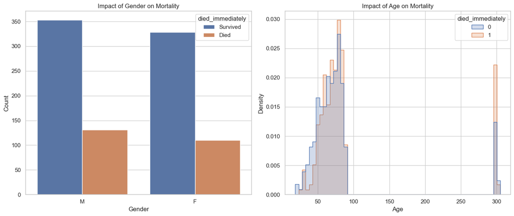

```python
sns.set(style="whitegrid")

fig, ax = plt.subplots(1, 2, figsize=(14, 6))
sns.countplot(x='gender', hue='died_immediately', data=data, ax=ax[0])
ax[0].set_title('Impact of Gender on Mortality')
ax[0].set_xlabel('Gender')
ax[0].set_ylabel('Count')
ax[0].legend(title='died_immediately', labels=['Survived', 'Died'])

sns.histplot(data=data, x='age', hue='died_immediately', element='step', stat='density', common_norm=False, ax=ax[1])
ax[1].set_title('Impact of Age on Mortality')
ax[1].set_xlabel('Age')
ax[1].set_ylabel('Density')

plt.tight_layout()
plt.show()
```

The gender is balanced, and the death rate within each gender also consistants with each other.

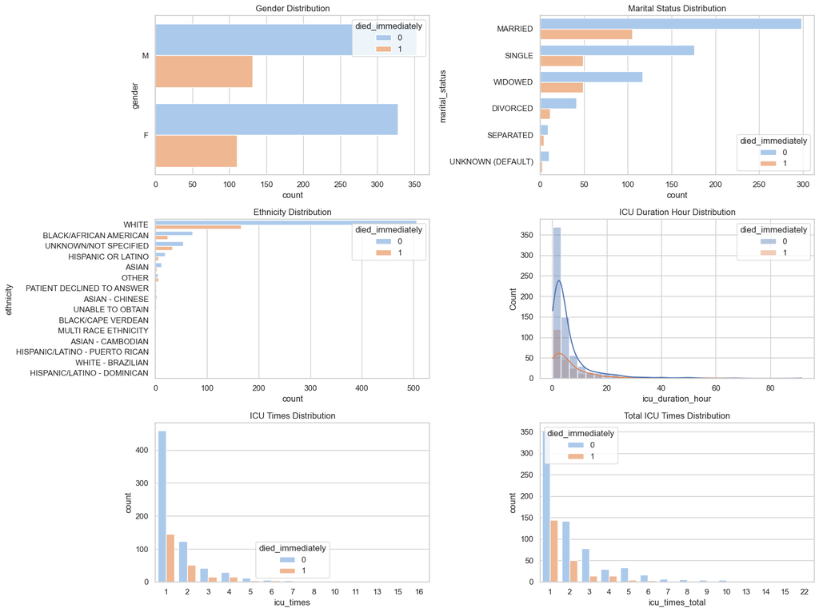

```python
marital_status_order = data['marital_status'].value_counts().index
ethnicity_order = data['ethnicity'].value_counts().index

fig, axes = plt.subplots(3, 2, figsize=(16, 12))

sns.countplot(y='gender', data=data, hue='died_immediately', ax=axes[0, 0], palette='pastel')
axes[0, 0].set_title('Gender Distribution')

sns.countplot(y='marital_status', data=data, order=marital_status_order, hue='died_immediately', ax=axes[0, 1], palette='pastel')
axes[0, 1].set_title('Marital Status Distribution')

sns.countplot(y='ethnicity', data=data, order=ethnicity_order, hue='died_immediately', ax=axes[1, 0], palette='pastel')
axes[1, 0].set_title('Ethnicity Distribution')

sns.histplot(data=data, x='icu_duration_hour', hue='died_immediately', bins=30, kde=True, ax=axes[1, 1], alpha=0.4)
axes[1, 1].set_title('ICU Duration Hour Distribution')

sns.countplot(x='icu_times', data=data, hue='died_immediately', ax=axes[2, 0], palette='pastel')
axes[2, 0].set_title('ICU Times Distribution')

sns.countplot(x='icu_times_total', data=data, hue='died_immediately', ax=axes[2, 1], palette='pastel')
axes[2, 1].set_title('Total ICU Times Distribution')

plt.tight_layout()
plt.show()
```

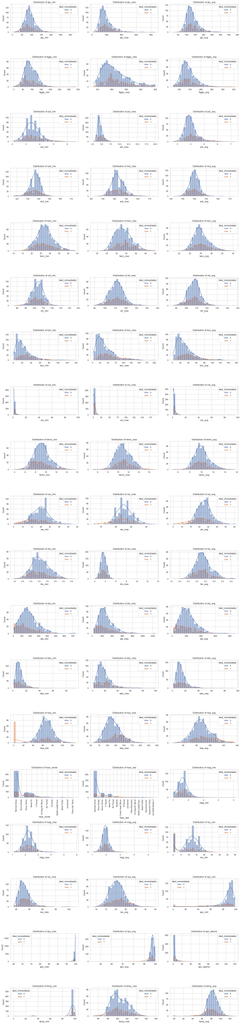

```python
import matplotlib.pyplot as plt
import pandas as pd
import seaborn as sns

# 读取 CSV 文件
file_path = 'F:/STUDY/python_code/Pract_DA/prepocess/patient_sepsis_all_dropdup_dropnull25.csv'
data = pd.read_csv(file_path)

test_columns = data.columns[12:-3]  # 获取要绘制的列

# 计算行数
rows = (len(test_columns) + 2) // 3

# 创建子图
fig, axes = plt.subplots(rows, 3, figsize=(18, rows * 4))
axes = axes.flatten()

# 遍历列并绘制图表
for i, col in enumerate(test_columns):
    sns.histplot(data=data, x=col, hue='died_immediately', ax=axes[i], bins=30, kde=True, alpha=0.5)
    axes[i].set_title(f'Distribution of {col}')
    if col == 'hear_mode' or col == 'hear_last':
        axes[i].tick_params(axis='x', rotation=90)

# 隐藏多余的子图
for j in range(i + 1, len(axes)):
    axes[j].set_visible(False)

# 调整布局
plt.tight_layout()
plt.show()
```

Most values follows normal distribution and shows a strong correlation with the distribution of the values.

**Hea_min**, as an example, with extremely low values will clearly lead to death.

# Box plots to identify ourliers

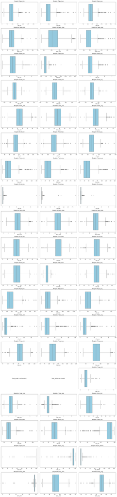

```python
import matplotlib.pyplot as plt
import pandas as pd
import seaborn as sns

file_path = 'F:\STUDY\python_code\Pract_DA\prepocess\patient_sepsis_all_dropdup_dropnull25.csv'
data = pd.read_csv(file_path)

test_columns = data.columns[12:-3]

rows = (len(test_columns) + 2) // 3

fig, axes = plt.subplots(rows, 3, figsize=(18, rows * 4))
axes = axes.flatten()

for i, col in enumerate(test_columns):
    if data[col].dtype in ['float64', 'int64']:  # Numeric data: Vertical boxplot
        sns.boxplot(data=data, x=col, ax=axes[i], color='skyblue')
        axes[i].set_title(f'Boxplot of {col}')
    else:  # Categorical data can't be used in boxplots, so we skip those cases
        axes[i].text(0.5, 0.5, f"{col} is not numeric",
                     ha='center', va='center', fontsize=12)
        axes[i].set_axis_off()

for j in range(i + 1, len(axes)):
    axes[j].set_visible(False)

plt.tight_layout()
plt.show()
```

# What's next?

### **1, Further preprocess the data**

#### Outliers and Null values

For outliers that are obviously impossible to happen, like age being over 200 years as shown in the histgraph of age, we will use average to subsitute them.

For outliers that are possible to happen, like extram values in medical test values, we tend to preserve them for now to keep as much information as possible about the patient.

For numeric null values, we will use the average to fill them.

For text null values, we will use the mode to fill them.

Another kind of outliers is text values being 'other' or 'unknown' like in **Marital stats**, we will use the mode to substitute them.

#### Text values

For gender, the distribution is balanced, so we can use 0/1 to represent male/female.

For marital status, since there are not too many different values, we tend to use one-hot encoding.

For ethnicity, the majority is white, and most death happened in white, and other ethnicities only have a very small portition comparing to white. Therefore, we tend to use 'white' and 'non-white' to substitute the current values. Then use 0/1 to represent them as well.

### **2, Model to be used**

We plan to use a simple CNN to see how it will behave on this unbalanced dataset, and then decide whether we need an outlier detection model.